# ST558 - Project 2

Tyler Pollard & Lucy Yin

# Introduction

For this report we will be using 6 models (4 linear regression, 1 random forest model, 1 boosted tree model) to make predictions on the total count of bike riders using data from the Bike Sharing Dataset (dataset can be found [here](https://archive.ics.uci.edu/ml/datasets/Bike+Sharing+Dataset)). This dataset contains hourly and daily count of registered, casual, and total sum of riders in the Capital bikeshare system, contributing variables include:

- season (winter, spring, summer, fall)
- year (2011, 2012)
- month of the year
- hour of the day
- holiday (yes, no)
- day of the week
- working day (yes or no)
- weather situation (mostly clear, mist, light precipitation, heavy precipitation)
- temperature
- feeling temperature
- humidity
- wind speed

There are 3 different types of response variables in the dataset:

- registered: registered riders who uses this bikeshare service regularly
- casual: un-registered riders who use this service casually or on occasions
- total: combined count of registered and casual riders

For our analysis, we will be working with almost of the variables as predictors, and our response variable will be the total count of bike riders.

We will be selecting predictors using the `step()` function which chooses a model by AIC in a stepwise algorithm. As a result, which predictors we incorporate in our linear regression models and ensemble tree (specifically random forest and boosted tree) models may differ depending on which day of the week we look at. We’ll randomly split the data into training and test sets and fit the 6 models on the training set. Ultimately we’re will fit the 6 models on test set and decide on which model produced better prediction, which we judge by the smallest root mean squared error value.

# Data

First we will read in both the `hours.csv` and `day.csv` data.

```r
# read in data
hour.data <- read_csv("data/hour.csv") %>% as_tibble()
day.data <- read_csv("data/day.csv") %>% as_tibble()
```

We will make corrections on variable types, specifically we’re making sure categorical variables will be appropriately classified as factors with clear levels.

```r
# correct the variable types
hour.data$season <- factor(hour.data$season)
levels(hour.data$season) <- list(winter = 1, spring = 2, summer = 3, fall = 4)

hour.data$yr <- factor(hour.data$yr)
levels(hour.data$yr) <- list("2011" = 0, "2012" = 1)

hour.data$weekday <- factor(hour.data$weekday)
levels(hour.data$weekday) <- list(monday = 1, tuesday = 2, wednesday = 3, thursday = 4, friday = 5, saturday = 6, sunday = 0)

hour.data$mnth <- factor(hour.data$mnth)
hour.data$hr <- factor(hour.data$hr)
hour.data$holiday <- factor(hour.data$holiday)
hour.data$workingday <- factor(hour.data$workingday)
hour.data$weathersit <- factor(hour.data$weathersit)

day.data$season <- factor(day.data$season)
levels(day.data$season) <- list(winter = 1, spring = 2, summer = 3, fall = 4)

day.data$yr <- factor(day.data$yr)
levels(day.data$yr) <- list("2011" = 0, "2012" = 1)

day.data$weekday <- factor(day.data$weekday)
levels(day.data$weekday) <- list(monday = 1, tuesday = 2, wednesday = 3, thursday = 4, friday = 5, saturday = 6, sunday = 0)

day.data$mnth <- factor(day.data$mnth)
day.data$holiday <- factor(day.data$holiday)
day.data$workingday <- factor(day.data$workingday)
day.data$weathersit <- factor(day.data$weathersit)
```

Because the variables temperature, feeling temperature, humidity and windspeed are normalized according to different measures, we will un-normalize them and save the raw values as separate columns in the dataset.

```r
# Temp Unnormal
temp.tmin = -8
temp.tmax = 39
hour.data$temp.unnormal <- hour.data$temp*(temp.tmax - temp.tmin) + temp.tmin # Unnormalize temp
hour.data$temp.F <- hour.data$temp.unnormal*(9/5) + 32 # Convert to Fahrenheit
day.data$temp.unnormal <- hour.data %>% group_by(dteday) %>% summarise(mean = mean(temp.unnormal)) %>% select(mean)
day.data$temp.unnormal <- day.data$temp.unnormal[[1]]
day.data$temp.F <- hour.data %>% group_by(dteday) %>% summarise(mean = mean(temp.F)) %>% select(mean)
day.data$temp.F <- day.data$temp.F[[1]]

# Atemp Unnormal
atemp.tmin = -16
atemp.tmax = 50
hour.data$atemp.unnormal <- hour.data$atemp*(atemp.tmax - atemp.tmin) + atemp.tmin # Unnormalize atemps
hour.data$atemp.F <- hour.data$atemp.unnormal*(9/5) + 32 # Convert to Fahrenheit
day.data$atemp.unnormal <- hour.data %>% group_by(dteday) %>% summarise(mean = mean(atemp.unnormal)) %>% select(mean)
day.data$atemp.unnormal <- day.data$atemp.unnormal[[1]]
day.data$atemp.F <- hour.data %>% group_by(dteday) %>% summarise(mean = mean(atemp.F)) %>% select(mean)
day.data$atemp.F <- day.data$atemp.F[[1]]

# Humidity Unnormal
day.data$hum.unnormal <- day.data$hum * 100
hour.data$hum.unnormal <- hour.data$hum * 100

# Windspeed Unnormal
day.data$windspeed.unnormal <- day.data$windspeed * 67
hour.data$windspeed.unnormal <- hour.data$windspeed * 67
```

Because hour and day data are stored separately, we create a `total.data` table with all the information combined just in case we need to access this in later steps.

```r
# add in a new variable before merging
hour.data <- mutate(hour.data, type = "hour")
day.data <- mutate(day.data, type = "day", hr = NA) %>% select(instant, dteday, season, yr, mnth, hr, everything())

# merge to create complete list of hour/day data
total.data <- rbind(hour.data, day.data)
```

We will filter to only include data from one specific day of the week at a time.

```r
# filter out to one specific day of the week
hour.data <- hour.data %>% filter(weekday == params$weekday)
day.data <- day.data %>% filter(weekday == params$weekday)
total.data <- total.data %>% filter(weekday == params$weekday)
```

We randomly sample from the filtered data to form a training set (with 70% of data) and test set (with the remaining 30% of data). Here we randomly sampled from the day dataset and split it into training and test sets, then we split the corresponding data from the hours dataset according to which days are in the training set and which days are in the test set. We will be using the hours dataset for our modeling, but we wanted to make sure our day and hour datasets had matching training and test splits.

```r
# splitting data into training & test sets
set.seed(7)
train <- sample(1:nrow(day.data), size = nrow(day.data)*0.7)
test <- dplyr::setdiff(1:nrow(day.data), train)
day.training.data <- day.data[train, ]
day.test.data <- day.data[test, ]

hour.training.data <- hour.data[hour.data$dteday %in% day.training.data$dteday,]
hour.test.data <- hour.data[hour.data$dteday %in% day.test.data$dteday,]
```

# Summarization

We have some basic summary statistics and plots about our training data.

## Contingency Tables

### Weather Situation

```r
levels(day.training.data$weathersit) <- list(
  "Clear, Few clouds, Partly cloudy, Partly cloudy" = "1",
  "Mist + Cloudy, Mist + Broken clouds, Mist + Few clouds, Mist" = "2",
  "Light Snow, Light Rain + Thunderstorm + Scattered clouds, Light Rain + Scattered clouds" = "3",
  "Heavy Rain + Ice Pallets + Thunderstorm + Mist, Snow + Fog" = "4")
kable(t(table(day.training.data$weathersit)))
```

| Clear, Few clouds, Partly cloudy, Partly cloudy | Mist + Cloudy, Mist + Broken clouds, Mist + Few clouds, Mist | Light Snow, Light Rain + Thunderstorm + Scattered clouds, Light Rain + Scattered clouds | Heavy Rain + Ice Pallets + Thunderstorm + Mist, Snow + Fog |
| --- | --- | --- | --- |
| 44 | 28 | 1 | 0 |

### Year, Season and Count of Riders

These contingency tables show what count range of riders utilized the bikeshare service for a given season or for a given year. This table can help us see if the number of riders increased/decreased from 2011 to 2012, or if season has an effect on how many riders used the bikeshare service.

```r
kable(table(day.training.data$season, cut(day.training.data$cnt, breaks = 2)), caption = "Occurrences of # Range of Riders of a given Season")
```

Occurrences of # Range of Riders of a given Season

|  | (913,4.22e+03] | (4.22e+03,7.53e+03] |
| --- | --- | --- |
| winter | 14 | 0 |
| spring | 7 | 11 |
| summer | 3 | 18 |
| fall | 7 | 13 |

```r
kable(table(day.training.data$yr, cut(day.training.data$cnt, breaks = 2)), caption = "Occurrences of # Range of Riders of a given Year")
```

Occurrences of # Range of Riders of a given Year

|  | (913,4.22e+03] | (4.22e+03,7.53e+03] |
| --- | --- | --- |
| 2011 | 23 | 13 |
| 2012 | 8 | 29 |

### Working Day and Count of Casual Riders

This contingency table show what count range of casual riders utilized the bikeshare service on working day versus non-working day. Intuitively we’d suspect that there would more casual riders on non-workingday than working day, this table can show us whether it’s true or not.

```r
levels(day.training.data$workingday) <- list("workday" = 1, "non-workday" = 0)
kable(table(day.training.data$workingday, cut(day.training.data$casual, breaks = 2)), caption = "Occurrences of # Range of Casual Riders of Workday vs. non-Workday")
```

Occurrences of # Range of Casual Riders of Workday vs. non-Workday

|  | (38.5,1.3e+03] | (1.3e+03,2.56e+03] |
| --- | --- | --- |
| workday | 62 | 0 |
| non-workday | 7 | 4 |

## Summary Tables

### Feeling Temperature

This summary table shows the spread of feeling temperatures for each year. The table includes the 5 number summary along with mean and standard deviation, which gives insight to the range of feeling temperatures riders experienced.

```r
atemp.summary <- hour.training.data %>% group_by(yr) %>% summarise(mean = mean(atemp.F), sd = sd(atemp.F), min = min(atemp.F), Q1 = quantile(atemp.F,0.25), median = median(atemp.F), Q3 = quantile(atemp.F, 0.75), max = max(atemp.F))
kable(atemp.summary, digits = 2, caption = "Feeling Temperature")
```

Feeling Temperature

| yr | mean | sd | min | Q1 | median | Q3 | max |
| --- | --- | --- | --- | --- | --- | --- | --- |
| 2011 | 59.87 | 22.11 | 6.8 | 42.8 | 62.6 | 77 | 104.0 |
| 2012 | 62.38 | 19.05 | 15.8 | 50.0 | 62.6 | 77 | 100.4 |

### Humidity

These summary tables show the spread of normalized and raw humidity values. The table includes the 5 number summary along with mean and standard deviation, which gives insight to the range of humidity levels riders experienced.

```r
kable(t(c(summary(day.training.data$hum), St.Dev. = sd(day.training.data$hum))), digits = 2, caption = "Normalized Humidity")
```

Normalized Humidity

| Min. | 1st Qu. | Median | Mean | 3rd Qu. | Max. | St.Dev. |
| --- | --- | --- | --- | --- | --- | --- |
| 0.32 | 0.55 | 0.66 | 0.65 | 0.74 | 0.92 | 0.13 |

```r
kable(t(c(summary(day.training.data$hum.unnormal), St.Dev. = sd(day.training.data$hum.unnormal))), digits = 2, caption = "Raw Humidity")
```

Raw Humidity

| Min. | 1st Qu. | Median | Mean | 3rd Qu. | Max. | St.Dev. |
| --- | --- | --- | --- | --- | --- | --- |
| 31.75 | 55.08 | 65.83 | 64.98 | 74.17 | 92.5 | 13.1 |

### Wind Speed

These summary tables show the spread of normalized and raw wind speeds. The table includes the 5 number summary along with mean and standard deviation, which gives insight to the range of wind speeds riders experienced.

```r
kable(t(c(summary(day.training.data$windspeed), St.Dev. = sd(day.training.data$windspeed))), digits = 2, caption = "Normalized Wind Speed")
```

Normalized Wind Speed

| Min. | 1st Qu. | Median | Mean | 3rd Qu. | Max. | St.Dev. |
| --- | --- | --- | --- | --- | --- | --- |
| 0.04 | 0.13 | 0.17 | 0.19 | 0.23 | 0.39 | 0.08 |

```r
kable(t(c(summary(day.training.data$windspeed.unnormal), St.Dev. = sd(day.training.data$windspeed.unnormal))), digits = 2, caption = "Raw Wind Speed ")
```

Raw Wind Speed

| Min. | 1st Qu. | Median | Mean | 3rd Qu. | Max. | St.Dev. |
| --- | --- | --- | --- | --- | --- | --- |
| 2.83 | 8.71 | 11.58 | 12.49 | 15.67 | 25.92 | 5.54 |

## Histograms

### Humidity and Windspeed Distributions

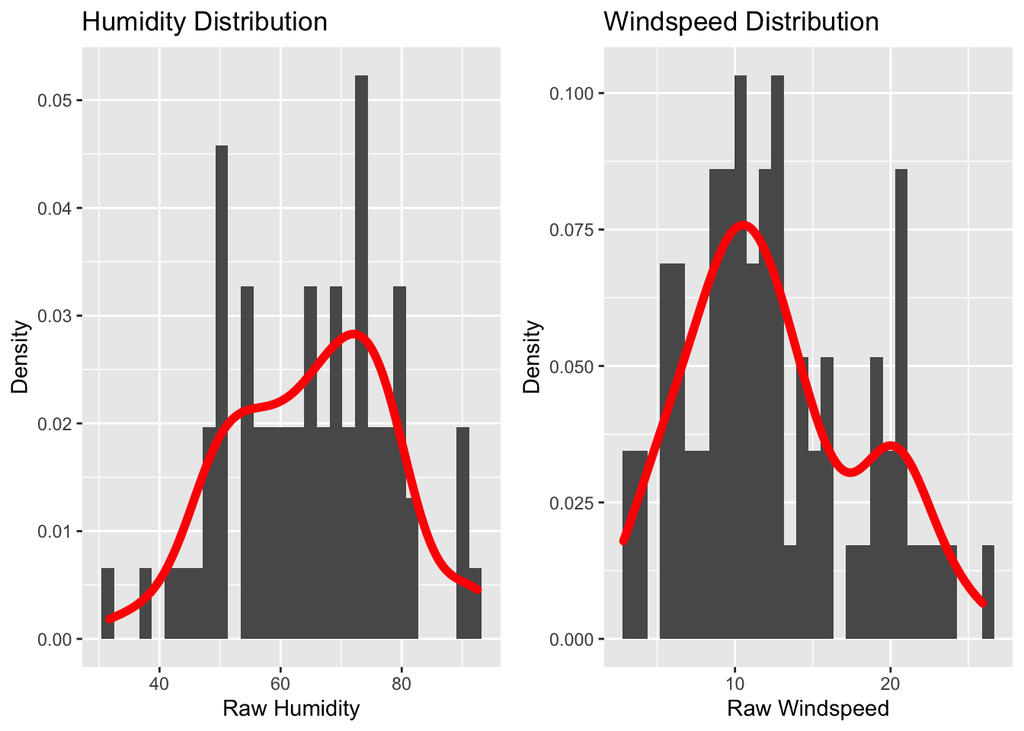

```r
hum.histogram <- ggplot(data = day.training.data, aes(x = hum.unnormal)) +
  geom_histogram(aes(y = ..density..), bins = 30) +
  geom_density(color = "red", size = 2) +
  labs(title = "Humidity Distribution", x = "Raw Humidity", y = "Density")
windspeed.histogram <- ggplot(data = day.training.data, aes(x = windspeed.unnormal)) +
  geom_histogram(aes(y = ..density..), bins = 30) +
  geom_density(color = "red", size = 2) +
  labs(title = "Windspeed Distribution", x = "Raw Windspeed", y = "Density")
grid.arrange(hum.histogram, windspeed.histogram, ncol = 2)
```

## Density Plot

### Casual Riders and Weather Situation

This density plot shows the amount of casual riders in a given weather situation. Intuitively we suspect that there would more casual riders in better weather conditions. This density plot can show us whether or not this is true.

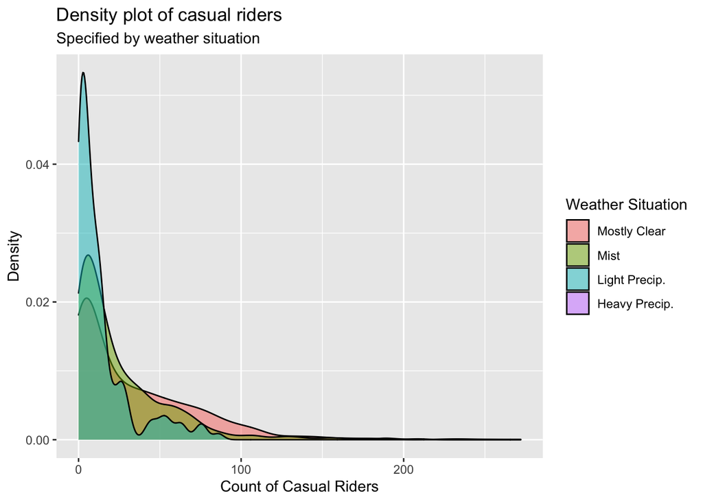

```r
ggplot(hour.training.data, aes(x = casual)) +
  geom_density(alpha = 0.5, aes(fill = weathersit)) +
  labs(title = "Density plot of casual riders",
       subtitle = "Specified by weather situation",
       x = "Count of Casual Riders",
       y = "Density") +
  scale_fill_discrete(name = "Weather Situation", labels = c("Mostly Clear", "Mist", "Light Precip.", "Heavy Precip."))
```

### Registered Riders and Weather Situation

This density plot shows the amount of registered riders in a given weather situation. We suspect that the amount of registered riders wouldn’t be as affected by weather situation as the amount of casual riders would. This density plot can show us whether or not this is true.

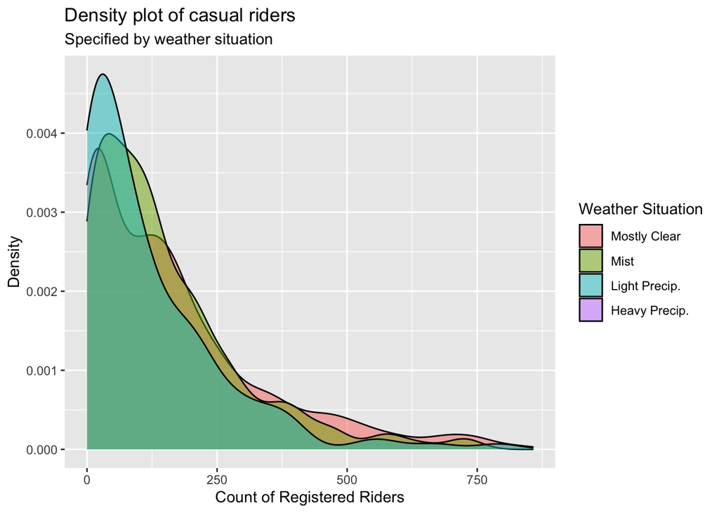

```r
ggplot(hour.training.data, aes(x = registered)) +
  geom_density(alpha = 0.5, aes(fill = weathersit)) +
  labs(title = "Density plot of casual riders",
       subtitle = "Specified by weather situation",
       x = "Count of Registered Riders",
       y = "Density") +
  scale_fill_discrete(name = "Weather Situation", labels = c("Mostly Clear", "Mist", "Light Precip.", "Heavy Precip."))
```

### Total Riders and Weather Situation

This density plot shows the total count of riders in a given weather situation. We may see a relationship between how many riders there are and what type of weather condition it is.

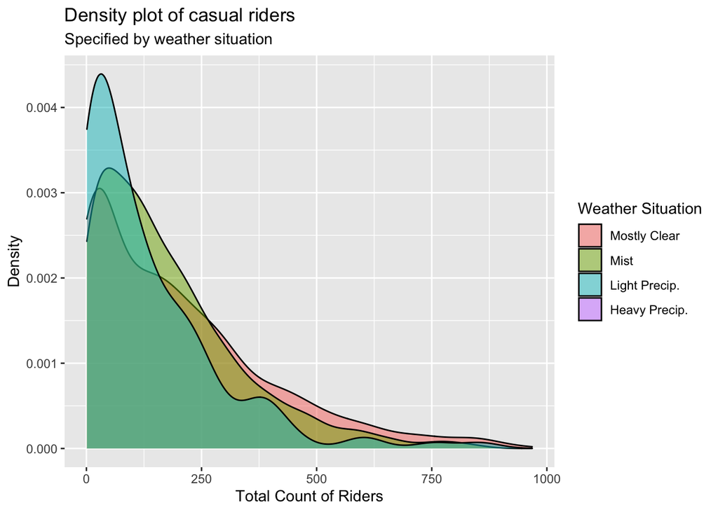

```r
ggplot(hour.training.data, aes(x = cnt)) +
  geom_density(alpha = 0.5, aes(fill = weathersit)) +
  labs(title = "Density plot of casual riders",
       subtitle = "Specified by weather situation",
       x = "Total Count of Riders",
       y = "Density") +
  scale_fill_discrete(name = "Weather Situation", labels = c("Mostly Clear", "Mist", "Light Precip.", "Heavy Precip."))
```

### Casual Riders and Holiday

This density plot shows the amount of casual riders depending on whether it is a holiday or non-holiday. We suspect there would be more casual riders on holidays, especially at larger counts. This density plot can show us whether that is true.

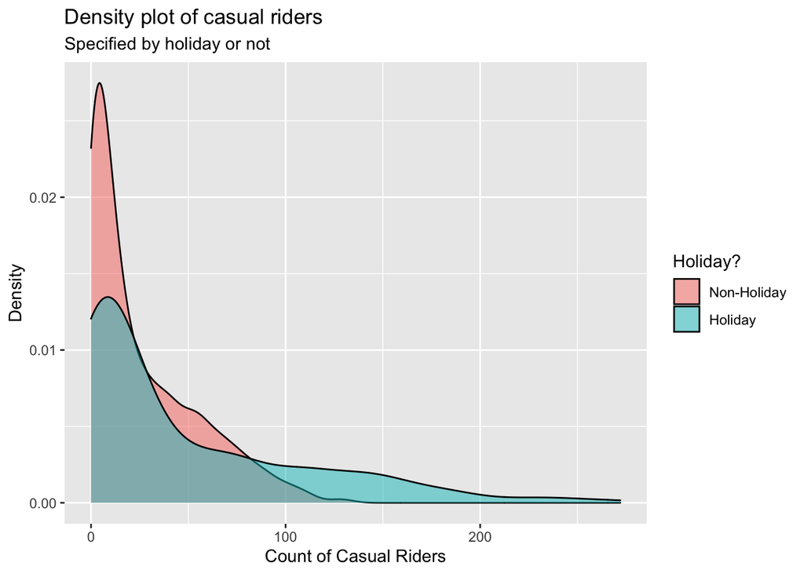

```r
ggplot(hour.training.data, aes(x = casual)) +
  geom_density(alpha = 0.5, aes(fill = holiday)) +
  labs(title = "Density plot of casual riders",
       subtitle = "Specified by holiday or not",
       x = "Count of Casual Riders",
       y = "Density") +
  scale_fill_discrete(name = "Holiday?", labels = c("Non-Holiday", "Holiday"))
```

### Registered Riders and Holiday

This density plot shows the amount of registered riders depending on whether it is a holiday or non-holiday. We suspect there would be more registered riders on non-holidays, especially at larger counts. This density plot can show us whether that is true.

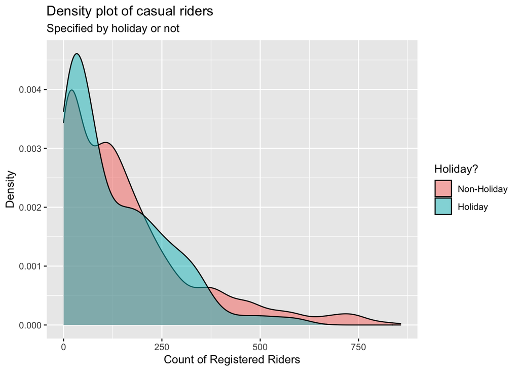

```r
ggplot(hour.training.data, aes(x = registered)) +
  geom_density(alpha = 0.5, aes(fill = holiday)) +
  labs(title = "Density plot of casual riders",
       subtitle = "Specified by holiday or not",
       x = "Count of Registered Riders",
       y = "Density") +
  scale_fill_discrete(name = "Holiday?", labels = c("Non-Holiday", "Holiday"))
```

### Total Riders and Holiday

This density plot shows the total count of riders depending on whether it is a holiday or non-holiday. This plot could show a relationship between the amount of riders versus whether it’s a holiday or non-holiday.

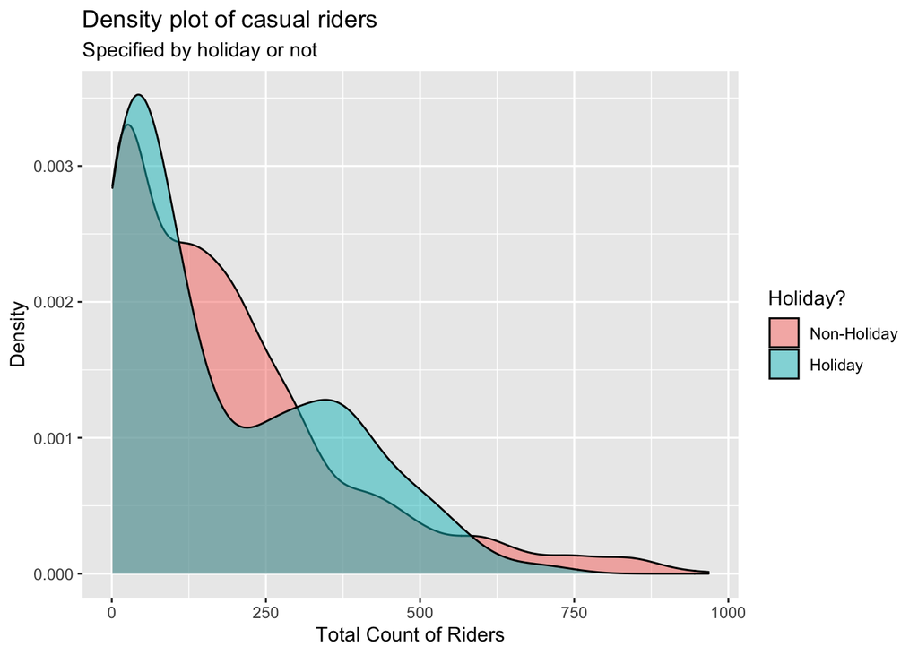

```r
ggplot(hour.training.data, aes(x = cnt)) +
  geom_density(alpha = 0.5, aes(fill = holiday)) +
  labs(title = "Density plot of casual riders",
       subtitle = "Specified by holiday or not",
       x = "Total Count of Riders",
       y = "Density") +
  scale_fill_discrete(name = "Holiday?", labels = c("Non-Holiday", "Holiday"))
```

## Boxplots

### Feeling Temperature Over the Year

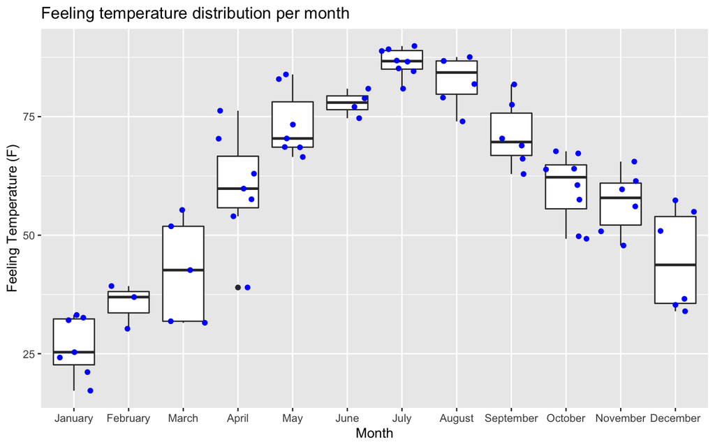

```r
atemp.boxplot.df <- day.training.data
levels(atemp.boxplot.df$mnth) <- list(January = 1, February = 2, March = 3, April = 4, May = 5, June = 6, July = 7, August = 8, September = 9, October = 10, November = 11, December = 12)
ggplot(data = atemp.boxplot.df, aes(x = mnth, y = atemp.F)) +
  geom_boxplot() +
  geom_point(position = "jitter", color = "blue") +
  labs(title = "Feeling temperature distribution per month", x = "Month", y = "Feeling Temperature (F)")
```

### Riders of Every Hour and Weather Situation

This boxplot shows the 5 number summary (in boxplot form with occasional outliers) of the amount of riders for each hour of the day. The colored lines should the mean number of riders for each given weather situation. We expect that the highest amount of riders should appear around the morning and afternoon commute time given it’s not on a holiday or on the weekends. This boxplot can show if that’s true.

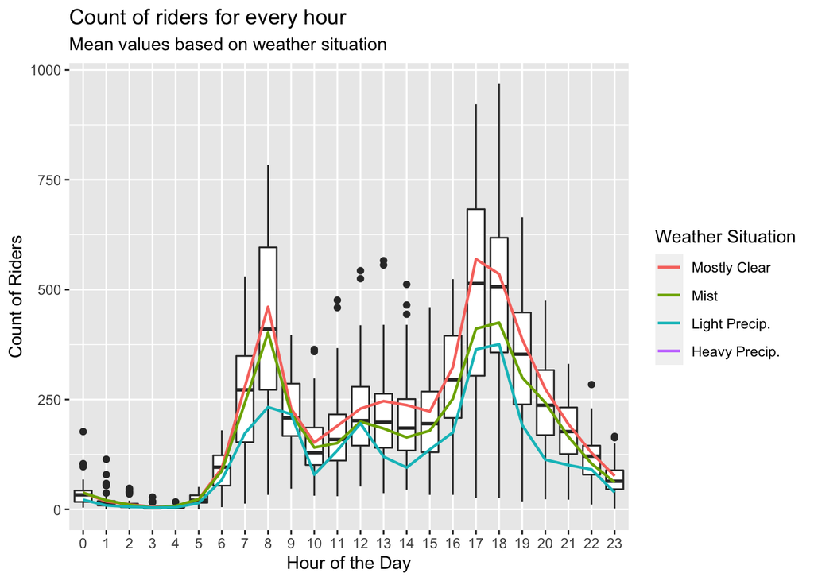

```r
ggplot(hour.training.data, aes(x = hr, y = cnt)) +
  geom_boxplot() +
  stat_summary(fun = mean, geom = "line", lwd = 0.8, aes(group = weathersit, col = weathersit)) +
  labs(title = "Count of riders for every hour",
       subtitle = "Mean values based on weather situation",
       x = "Hour of the Day",
       y = "Count of Riders") +
  scale_color_discrete(name = "Weather Situation", labels = c("Mostly Clear", "Mist", "Light Precip.", "Heavy Precip."))
```

## Scatter Plots

### Count vs Casual by Season

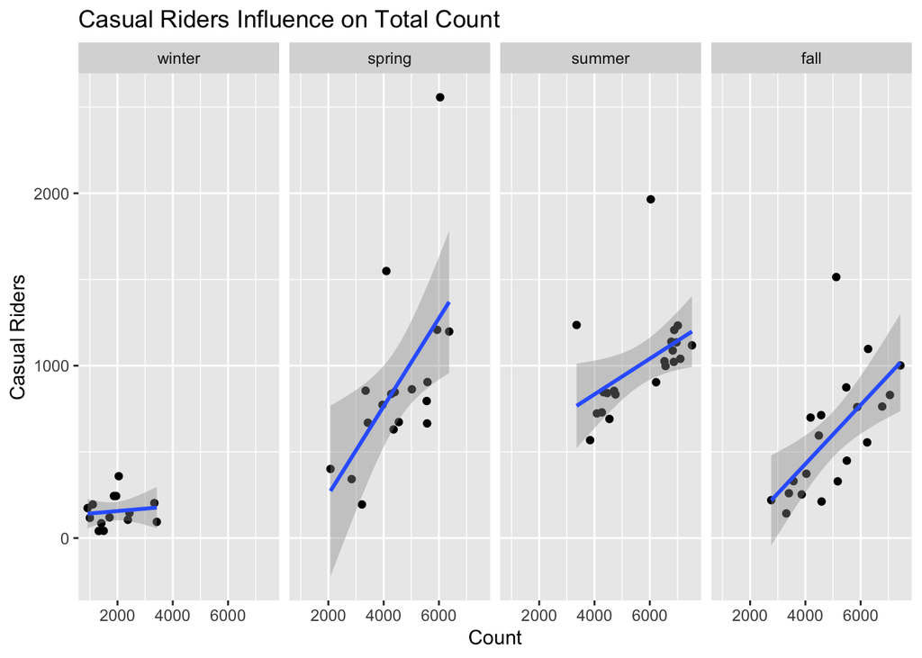

```r
ggplot(data = day.training.data, aes(x = cnt, y = casual)) +
  geom_point() +
  geom_smooth(method = "lm") +
  facet_grid(cols = vars(season)) +
  labs(title = "Casual Riders Influence on Total Count", x = "Count", y = "Casual Riders")
```

### Riders vs Temperature

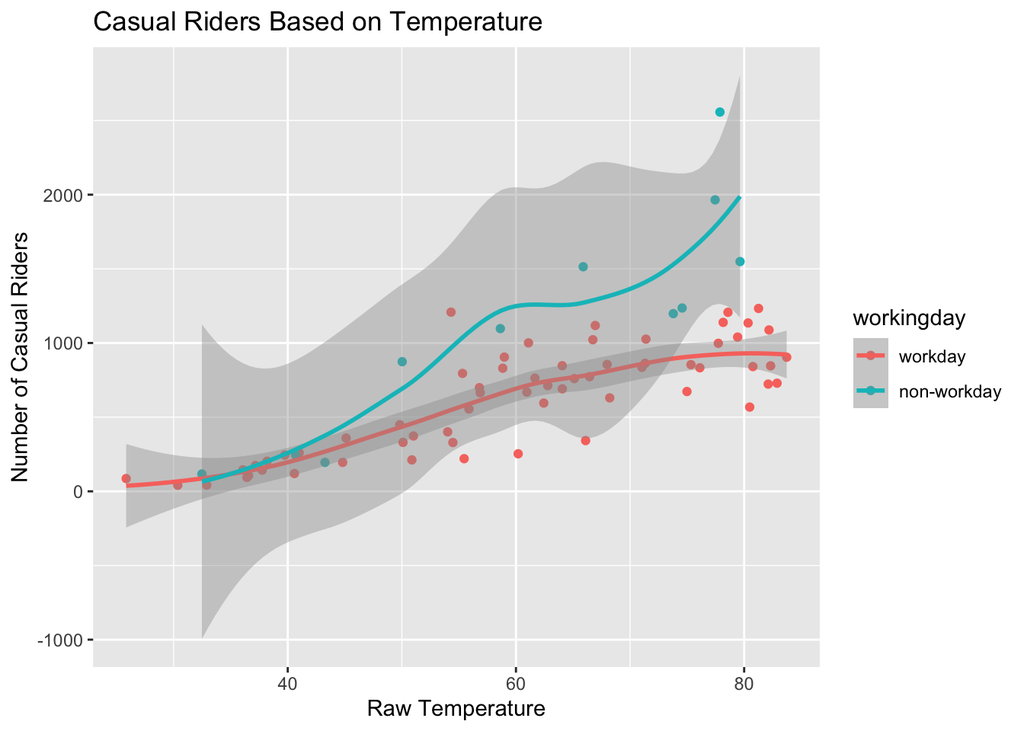

```r
# casual.scatter <- ggplot(data = day.training.data, aes(x = temp)) +
#   geom_point(aes(y = casual, color = "red"))
# registered.scatter <- ggplot(data = day.training.data, aes(x = temp)) +
#   geom_point(aes(y = registered, color = "blue"))
# grid.arrange(casual.scatter, registered.scatter, ncol =2)
day.training.data$temp.indicator <- ifelse(day.training.data$temp < mean(day.training.data$temp), 0, 1)
day.training.data$temp.indicator <- as_factor(day.training.data$temp.indicator)
levels(day.training.data$temp.indicator) <- list("Low Temperature" = 0, "High Temperature" = 1)
ggplot(data = day.training.data, aes(x = temp.F, y = casual, color = workingday)) +
  geom_point() +
  geom_smooth() + #method = "lm"
  #facet_grid(cols = vars(temp.indicator)) +
  labs(title = "Casual Riders Based on Temperature", x = "Raw Temperature", y = "Number of Casual Riders")
```

### Riders vs. Hour vs. Month vs. Working Day

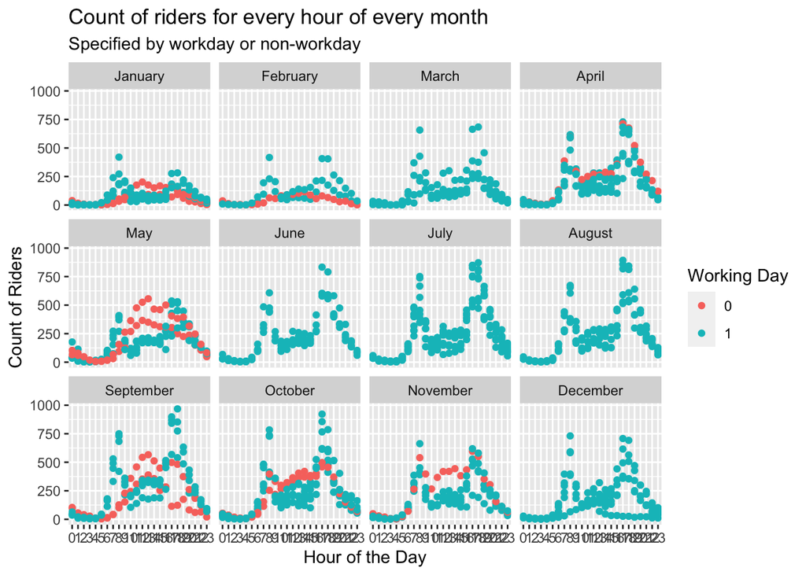

```r
count.df <- hour.training.data
levels(count.df$mnth) <- list(January = 1, February = 2, March = 3, April = 4, May = 5, June = 6, July = 7, August = 8, September = 9, October = 10, November = 11, December = 12)
ggplot(count.df, aes(x = hr, y = cnt)) +
  geom_point(aes(col = workingday)) +
  facet_wrap(vars(mnth)) +
  labs(title = "Count of riders for every hour of every month",
       subtitle = "Specified by workday or non-workday",
       x = "Hour of the Day",
       y = "Count of Riders") +
  scale_color_discrete(name = "Working Day")
```

## Correlation Plot

### Correlation between temp, atemp, hum, windspeed

This correlation plots show the correlation (positive or negative) between the 4 quantitative variables temperature, feeling temperature, humidity and wind speed. We suspect that there likely would be a high correlation between temperature and feeling temperature, and humidity might be inverse correlated with wind speed. This correlation can show us whether this is true.

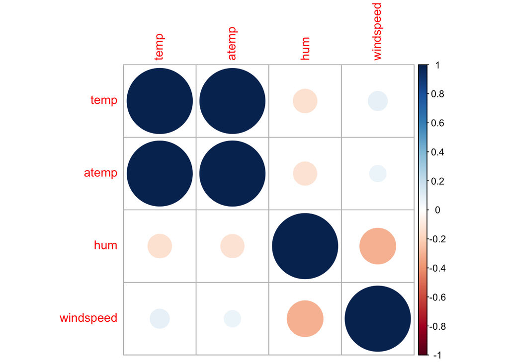

```r
cor.variables <- hour.training.data %>% select(temp, atemp, hum, windspeed)
correlation <- cor(cor.variables, method = "spearman")
corrplot(correlation)
```

## Plots with GGally

The two GGally plots below will show whether there’s any relationship between each of the variables. We run this plot on both the day and hour data.  
### Using Day Data

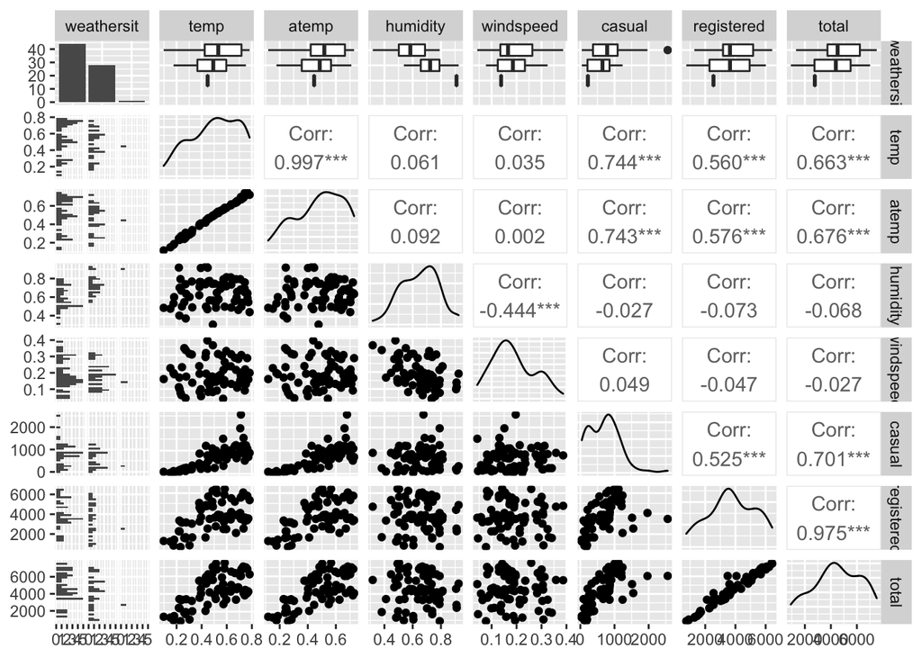

```r
subset.data.day <- data_frame(weathersit=day.training.data$weathersit, temp=day.training.data$temp, atemp=day.training.data$atemp,humidity=day.training.data$hum, windspeed=day.training.data$windspeed, casual=day.training.data$casual, registered=day.training.data$registered, total=day.training.data$cnt)
GGally::ggpairs(subset.data.day)
```

### Using Hour Data

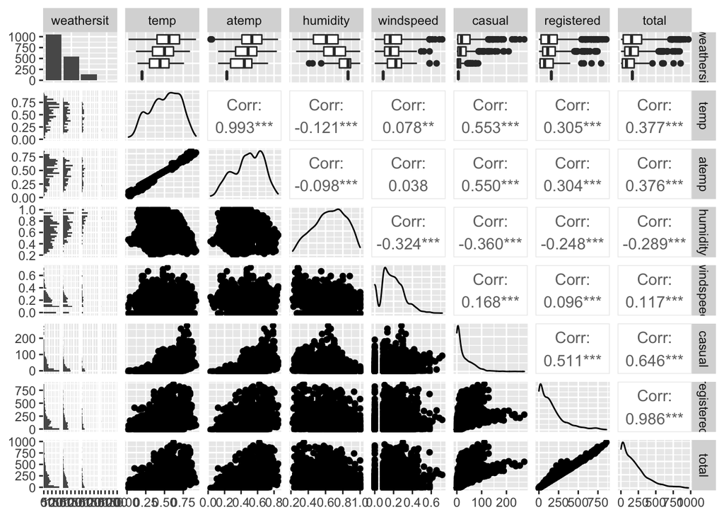

```r
subset.data.hr <- data_frame(weathersit=hour.training.data$weathersit, temp=hour.training.data$temp, atemp=hour.training.data$atemp,humidity=hour.training.data$hum, windspeed=hour.training.data$windspeed, casual=hour.training.data$casual, registered=hour.training.data$registered, total=hour.training.data$cnt)
GGally::ggpairs(subset.data.hr)
```

# Modeling

## Linear Regression Model

### Picking predictors using AIC

First we want to select only the variables that we will use in our models, as variables such as record index, date are not useful to us. We will be using the un-normalized versions of temperature, feeling temperature, humidity and wind speed (instead of the normalized versions) because we want to standardize all numerical variables when running our models. Because on some days of the week holiday and working day both become 1 leveled factor variables and can cause issues in our modeling, so we will omit these 2 variables for those days of the week.

```r
# keep only variables that are relevant to modeling
if.weekday <- hour.training.data %>% filter(weekday == params$weekday) %>% select(workingday) %>% unique() %>% nrow()
if.holiday <- hour.training.data %>% filter(weekday == params$weekday) %>% select(holiday) %>% unique() %>% nrow()

# use function to decide if a weekday has 1 factored levels
# if so we will not use these factors in the model
get.data <- function(weekday, ...){
  if (if.weekday == 1 & if.holiday == 1) {
    hour.training.data2 <- hour.training.data %>% select(season, yr, mnth, hr, weathersit, temp.F, atemp.F, hum.unnormal, windspeed.unnormal, cnt)
  }
  else {
    hour.training.data2 <- hour.training.data %>% select(season, yr, mnth, hr, holiday, workingday, weathersit, temp.F, atemp.F, hum.unnormal, windspeed.unnormal, cnt)
  }
  hour.training.data2
}
hour.training.data2 <- get.data(params$weekday)
```

We will let the `step()` function to pick our models using the stepwise algorithm. We provide the `step()` function with 3 different linear models, first with just first order variables, second with squared terms and interactions, and third with first ordered variables and interactions.

```r
# aic using only 1st ordered terms
fit.aic <- step((lm(cnt ~ ., data = hour.training.data2, verbose = FALSE)), direction = "both")
```

```
## Start:  AIC=15475.07
## cnt ~ season + yr + mnth + hr + holiday + workingday + weathersit +
##     temp.F + atemp.F + hum.unnormal + windspeed.unnormal
##
##
## Step:  AIC=15475.07
## cnt ~ season + yr + mnth + hr + holiday + weathersit + temp.F +
##     atemp.F + hum.unnormal + windspeed.unnormal
##
##                      Df Sum of Sq      RSS   AIC
## - windspeed.unnormal  1       655 11850750 15473
## - temp.F              1      5069 11855164 15474
## <none>                            11850095 15475
## - holiday             1     16072 11866167 15475
## - atemp.F             1     35258 11885352 15478
## - mnth               11    206049 12056144 15483
## - hum.unnormal        1    187118 12037213 15500
## - weathersit          3    365878 12215973 15522
## - season              3    416928 12267023 15529
## - yr                  1   2386511 14236606 15793
## - hr                 23  29044253 40894348 17588
##
## Step:  AIC=15473.17
## cnt ~ season + yr + mnth + hr + holiday + weathersit + temp.F +
##     atemp.F + hum.unnormal
##
##                      Df Sum of Sq      RSS   AIC
## - temp.F              1      4456 11855206 15472
## <none>                            11850750 15473
## - holiday             1     16021 11866771 15474
## + windspeed.unnormal  1       655 11850095 15475
## - atemp.F             1     35399 11886149 15476
## - mnth               11    205493 12056243 15481
## - hum.unnormal        1    200409 12051159 15500
## - weathersit          3    367708 12218458 15520
## - season              3    421515 12272265 15528
## - yr                  1   2397003 14247752 15792
## - hr                 23  29067662 40918412 17587
##
## Step:  AIC=15471.83
## cnt ~ season + yr + mnth + hr + holiday + weathersit + atemp.F +
##     hum.unnormal
##
##                      Df Sum of Sq      RSS   AIC
## <none>                            11855206 15472
## + temp.F              1      4456 11850750 15473
## - holiday             1     23665 11878871 15473
## + windspeed.unnormal  1        42 11855164 15474
## - mnth               11    203632 12058838 15480
## - atemp.F             1    173272 12028478 15495
## - hum.unnormal        1    195962 12051167 15498
## - weathersit          3    373781 12228987 15520
## - season              3    417255 12272461 15526
## - yr                  1   2404239 14259445 15792
## - hr                 23  29328672 41183878 17596
```

```r
# aic including squared terms and interactions
fit.aic2 <- step((lm(cnt ~ .^2 + I(temp.F^2) + I(atemp.F^2) + I(hum.unnormal^2) + I(windspeed.unnormal^2), data = hour.training.data2, verbose = FALSE)), direction = "both")
```

```
## Start:  AIC=13305.01
## cnt ~ (season + yr + mnth + hr + holiday + workingday + weathersit +
##     temp.F + atemp.F + hum.unnormal + windspeed.unnormal)^2 +
##     I(temp.F^2) + I(atemp.F^2) + I(hum.unnormal^2) + I(windspeed.unnormal^2)
##
##
## Step:  AIC=13305.01
## cnt ~ season + yr + mnth + hr + holiday + workingday + weathersit +
##     temp.F + atemp.F + hum.unnormal + windspeed.unnormal + I(temp.F^2) +
##     I(atemp.F^2) + I(hum.unnormal^2) + I(windspeed.unnormal^2) +
##     season:yr + season:mnth + season:hr + season:holiday + season:workingday +
##     season:weathersit + season:temp.F + season:atemp.F + season:hum.unnormal +
##     season:windspeed.unnormal + yr:mnth + yr:hr + yr:holiday +
##     yr:workingday + yr:weathersit + yr:temp.F + yr:atemp.F +
##     yr:hum.unnormal + yr:windspeed.unnormal + mnth:hr + mnth:holiday +
##     mnth:workingday + mnth:weathersit + mnth:temp.F + mnth:atemp.F +
##     mnth:hum.unnormal + mnth:windspeed.unnormal + hr:holiday +
##     hr:workingday + hr:weathersit + hr:temp.F + hr:atemp.F +
##     hr:hum.unnormal + hr:windspeed.unnormal + holiday:workingday +
##     holiday:weathersit + holiday:temp.F + holiday:atemp.F + holiday:hum.unnormal +
##     holiday:windspeed.unnormal + workingday:weathersit + workingday:temp.F +
##     workingday:atemp.F + workingday:hum.unnormal + weathersit:temp.F +
##     weathersit:atemp.F + weathersit:hum.unnormal + weathersit:windspeed.unnormal +
##     temp.F:atemp.F + temp.F:hum.unnormal + temp.F:windspeed.unnormal +
##     atemp.F:hum.unnormal + atemp.F:windspeed.unnormal + hum.unnormal:windspeed.unnormal
##
##
## Step:  AIC=13305.01
## cnt ~ season + yr + mnth + hr + holiday + workingday + weathersit +
##     temp.F + atemp.F + hum.unnormal + windspeed.unnormal + I(temp.F^2) +
##     I(atemp.F^2) + I(hum.unnormal^2) + I(windspeed.unnormal^2) +
##     season:yr + season:mnth + season:hr + season:holiday + season:workingday +
##     season:weathersit + season:temp.F + season:atemp.F + season:hum.unnormal +
##     season:windspeed.unnormal + yr:mnth + yr:hr + yr:holiday +
##     yr:workingday + yr:weathersit + yr:temp.F + yr:atemp.F +
##     yr:hum.unnormal + yr:windspeed.unnormal + mnth:hr + mnth:holiday +
##     mnth:workingday + mnth:weathersit + mnth:temp.F + mnth:atemp.F +
##     mnth:hum.unnormal + mnth:windspeed.unnormal + hr:holiday +
##     hr:workingday + hr:weathersit + hr:temp.F + hr:atemp.F +
##     hr:hum.unnormal + hr:windspeed.unnormal + holiday:workingday +
```

[output cut: 1359 more lines]

```
## + mnth:hum.unnormal                11      9000 2283512 13241
## - mnth:temp.F                      11     50675 2343187 13242
## - yr:weathersit                     2     27278 2319790 13242
## + hr:atemp.F                       23     35897 2256616 13244
## + hr:windspeed.unnormal            23     27202 2265310 13251
## - mnth:weathersit                  22    103233 2395745 13259
## - mnth:holiday                      6     69310 2361822 13266
## - hr:temp.F                        23    132145 2424657 13278
## + mnth:hr                         253    524203 1768309 13279
## - yr:mnth                          10    132764 2425276 13304
## - hr:weathersit                    46    279055 2571567 13334
## - hr:hum.unnormal                  23    229211 2521723 13346
## - season:hr                        69    843749 3136261 13634
## - yr:hr                            23   1394617 3687129 14008
## - hr:holiday                       23   2022071 4314583 14282
```

```r
# aic using 1st order and interactions
fit.aic3 <- step((lm(cnt ~.^2, data = hour.training.data2, verbose = FALSE)), direction = "both")
```

```
## Start:  AIC=13321.92
## cnt ~ (season + yr + mnth + hr + holiday + workingday + weathersit +
##     temp.F + atemp.F + hum.unnormal + windspeed.unnormal)^2
##
##
## Step:  AIC=13321.92
## cnt ~ season + yr + mnth + hr + holiday + workingday + weathersit +
##     temp.F + atemp.F + hum.unnormal + windspeed.unnormal + season:yr +
##     season:mnth + season:hr + season:holiday + season:workingday +
##     season:weathersit + season:temp.F + season:atemp.F + season:hum.unnormal +
##     season:windspeed.unnormal + yr:mnth + yr:hr + yr:holiday +
##     yr:workingday + yr:weathersit + yr:temp.F + yr:atemp.F +
##     yr:hum.unnormal + yr:windspeed.unnormal + mnth:hr + mnth:holiday +
##     mnth:workingday + mnth:weathersit + mnth:temp.F + mnth:atemp.F +
##     mnth:hum.unnormal + mnth:windspeed.unnormal + hr:holiday +
##     hr:workingday + hr:weathersit + hr:temp.F + hr:atemp.F +
##     hr:hum.unnormal + hr:windspeed.unnormal + holiday:workingday +
##     holiday:weathersit + holiday:temp.F + holiday:atemp.F + holiday:hum.unnormal +
##     holiday:windspeed.unnormal + workingday:weathersit + workingday:temp.F +
##     workingday:atemp.F + workingday:hum.unnormal + weathersit:temp.F +
##     weathersit:atemp.F + weathersit:hum.unnormal + weathersit:windspeed.unnormal +
##     temp.F:atemp.F + temp.F:hum.unnormal + temp.F:windspeed.unnormal +
##     atemp.F:hum.unnormal + atemp.F:windspeed.unnormal + hum.unnormal:windspeed.unnormal
##
##
## Step:  AIC=13321.92
## cnt ~ season + yr + mnth + hr + holiday + workingday + weathersit +
##     temp.F + atemp.F + hum.unnormal + windspeed.unnormal + season:yr +
##     season:mnth + season:hr + season:holiday + season:workingday +
##     season:weathersit + season:temp.F + season:atemp.F + season:hum.unnormal +
##     season:windspeed.unnormal + yr:mnth + yr:hr + yr:holiday +
##     yr:workingday + yr:weathersit + yr:temp.F + yr:atemp.F +
##     yr:hum.unnormal + yr:windspeed.unnormal + mnth:hr + mnth:holiday +
##     mnth:workingday + mnth:weathersit + mnth:temp.F + mnth:atemp.F +
##     mnth:hum.unnormal + mnth:windspeed.unnormal + hr:holiday +
##     hr:workingday + hr:weathersit + hr:temp.F + hr:atemp.F +
##     hr:hum.unnormal + hr:windspeed.unnormal + holiday:workingday +
##     holiday:weathersit + holiday:temp.F + holiday:atemp.F + holiday:hum.unnormal +
##     holiday:windspeed.unnormal + workingday:weathersit + workingday:temp.F +
##     workingday:atemp.F + weathersit:temp.F + weathersit:atemp.F +
```

[output cut: 1306 more lines]

```
## - yr:weathersit                     2     31285 2347404 13253
## - weathersit:hum.unnormal           2     32934 2349053 13254
## - mnth:temp.F                      11     57632 2373750 13255
## + hr:atemp.F                       23     32994 2283125 13255
## + hr:windspeed.unnormal            23     31980 2284138 13256
## - mnth:weathersit                  22    112511 2428630 13272
## - mnth:holiday                      6     85291 2401409 13285
## + mnth:hr                         253    527499 1788620 13289
## - hr:temp.F                        23    142755 2458873 13292
## - yr:mnth                          10    136415 2452533 13314
## - hr:hum.unnormal                  23    217780 2533898 13344
## - hr:weathersit                    46    291614 2607733 13348
## - season:hr                        69    850458 3166577 13641
## - yr:hr                            23   1401369 3717488 14012
## - hr:holiday                       23   2083405 4399524 14306
```

### Modeling using AIC picked predictors

For the first linear regression model we run, we will pick predictors based on our intuition. We expect the feeling temperature would be highly correlated with the actual temperature, and because wind speed and humidity could also be correlated with feeling temperature, so we only kept temperature as a predictor in the model and will not include feeling temperature. We also did not include holiday in the model because it has some redundant information to the working day variable.

```r
# use all predictors except atemp and holiday
set.seed(7)
fit.mlr0 <- train(cnt ~ season + yr + mnth + hr + workingday + weathersit + temp.F + hum.unnormal + windspeed.unnormal,
                  data = hour.training.data,
                  method = "lm",
                  preProcess = c("center", "scale"),
                  trControl = trainControl(method = "cv", number = 10))
fit.mlr0
```

```
## Linear Regression
##
## 1743 samples
##    9 predictor
##
## Pre-processing: centered (45), scaled (45)
## Resampling: Cross-Validated (10 fold)
## Summary of sample sizes: 1568, 1569, 1569, 1569, 1569, 1569, ...
## Resampling results:
##
##   RMSE      Rsquared   MAE
##   85.05434  0.7829297  60.20054
##
## Tuning parameter 'intercept' was held constant at a value of TRUE
```

```r
# Examine performance of this multiple linear regression model on the test data after prediction
predict.mlr0 <- postResample(predict(fit.mlr0, newdata = hour.test.data), obs = hour.test.data$cnt)
```

The next three linear regression models are fit using the predictors picked by the three step functions. These models include different number of predictors in different complexity, so we will see which models will produce the best prediction in the end.

```r
# use aic predictors (1st ordered terms)
set.seed(7)
fit.mlr1 <- train(fit.aic$terms,
                  data = hour.training.data2,
                  method = "lm",
                  preProcess = c("center", "scale"),
                  trControl = trainControl(method = "cv", number = 10))
fit.mlr1
```

```
## Linear Regression
##
## 1743 samples
##    8 predictor
##
## Pre-processing: centered (44), scaled (44)
## Resampling: Cross-Validated (10 fold)
## Summary of sample sizes: 1568, 1569, 1569, 1569, 1569, 1569, ...
## Resampling results:
##
##   RMSE      Rsquared   MAE
##   84.88118  0.7839797  60.17589
##
## Tuning parameter 'intercept' was held constant at a value of TRUE
```

```r
# Examine performance of this multiple linear regression model on the test data after prediction
predict.mlr1 <- postResample(predict(fit.mlr1, newdata = hour.test.data), obs = hour.test.data$cnt)

# use aic predictors (2nd ordered terms and interactions)
set.seed(7)
fit.mlr2 <- train(fit.aic2$terms,
                  data = hour.training.data2,
                  method = "lm",
                  preProcess = c("center", "scale"),
                  trControl = trainControl(method = "cv", number = 10))
fit.mlr2
```

```
## Linear Regression
##
## 1743 samples
##   10 predictor
##
## Pre-processing: centered (398), scaled (398)
## Resampling: Cross-Validated (10 fold)
## Summary of sample sizes: 1568, 1569, 1569, 1569, 1569, 1569, ...
## Resampling results:
##
##   RMSE     Rsquared   MAE
##   48.2138  0.9297704  32.64087
##
## Tuning parameter 'intercept' was held constant at a value of TRUE
```

```r
# Examine performance of this multiple linear regression model on the test data after prediction
predict.mlr2 <- postResample(predict(fit.mlr2, newdata = hour.test.data), obs = hour.test.data$cnt)

# use aic predictors (1st order and interactions)
set.seed(7)
fit.mlr3 <- train(fit.aic3$terms,
                  data = hour.training.data2,
                  method = "lm",
                  preProcess = c("center", "scale"),
                  trControl = trainControl(method = "cv", number = 10))
fit.mlr3
```

```
## Linear Regression
##
## 1743 samples
##   10 predictor
##
## Pre-processing: centered (393), scaled (393)
## Resampling: Cross-Validated (10 fold)
## Summary of sample sizes: 1568, 1569, 1569, 1569, 1569, 1569, ...
## Resampling results:
##
##   RMSE      Rsquared   MAE
##   48.09445  0.9300816  32.68957
##
## Tuning parameter 'intercept' was held constant at a value of TRUE
```

```r
# Examine performance of this multiple linear regression model on the test data after prediction
predict.mlr3 <- postResample(predict(fit.mlr3, newdata = hour.test.data), obs = hour.test.data$cnt)
```

## Ensemble Tree Model

### Random Forest Model (tyler)

We first fit a random forest model using default tuning parameters, which produced a result with very large mtry values.

```r
# Fit random forest model
set.seed(7)
fit.random.forest.trial <- train(fit.aic$terms,
                           data = hour.training.data2,
                           method = "rf",
                           preProcess = c("center", "scale"),
                           trControl = trainControl(method = "cv", number = 10),
                           verbose = FALSE)
fit.random.forest.trial
```

```
## Random Forest
##
## 1743 samples
##    8 predictor
##
## Pre-processing: centered (44), scaled (44)
## Resampling: Cross-Validated (10 fold)
## Summary of sample sizes: 1568, 1569, 1569, 1569, 1569, 1569, ...
## Resampling results across tuning parameters:
##
##   mtry  RMSE       Rsquared   MAE
##    2    120.58913  0.7998780  90.92849
##   23     61.86774  0.8847339  41.11062
##   44     61.61511  0.8841101  39.71443
##
## RMSE was used to select the optimal model using the smallest value.
## The final value used for the model was mtry = 44.
```

We can manually tune our parameters to only include 1 to the number of predictors. We will use the result from this model to do predictions.

```r
set.seed(7)
fit.random.forest <- train(fit.aic$terms,
                           data = hour.training.data2,
                           method = "rf",
                           preProcess = c("center", "scale"),
                           trControl = trainControl(method = "cv", number = 10),
                           tuneGrid = data.frame(mtry = 1:(ncol(hour.training.data2) -1)))
fit.random.forest
```

```
## Random Forest
##
## 1743 samples
##    8 predictor
##
## Pre-processing: centered (44), scaled (44)
## Resampling: Cross-Validated (10 fold)
## Summary of sample sizes: 1568, 1569, 1569, 1569, 1569, 1569, ...
## Resampling results across tuning parameters:
##
##   mtry  RMSE       Rsquared   MAE
##    1    156.47473  0.7321613  120.08896
##    2    120.26453  0.7973103   90.60258
##    3     97.98913  0.8300044   72.56582
##    4     84.65290  0.8501054   61.87810
##    5     77.14741  0.8614257   55.80681
##    6     72.18630  0.8707242   51.63537
##    7     69.29402  0.8751672   49.01036
##    8     67.33540  0.8785049   47.33283
##    9     66.32093  0.8790240   46.23798
##   10     65.18360  0.8812858   45.28542
##   11     64.52238  0.8817790   44.55295
##
## RMSE was used to select the optimal model using the smallest value.
## The final value used for the model was mtry = 11.
```

```r
# Examine performance of random forest model on the test data after prediction
predict.rf <- postResample(predict(fit.random.forest, newdata = hour.test.data), obs = hour.test.data$cnt)
```

### Boosted Tree Model

The boosted tree model is a type of tree based method where we grow our trees in a sequential manner, each tree we create will be based off the previous tree so we can update our prediction as we go. For example, we’d fit our model and get a prediction, then create a new model based off the previous, update the prediction on this new model, and we’d repeat this process until we decide to stop. Boosted tree model slowly trains the trees to ensure we don’t overfit to our training data. How this is actually done is we create new residuals based off `observed - new predictions`, fit a tree to those residuals to get new predictions $\hat{y}$, then update our predictions again by a scaled down version of the new predictions $\lambda \hat{y}^{b}$ (here $\lambda$ is the growth rate tuning parameter, which keeps us from growing our predictions too quickly). We repeat this process a total of `B` times. We can use cross validation to select what $\lambda$, `d` and `B` should be. Formula used to update predictions is $\hat{y} = \hat{y} + \lambda \hat{y}^{b}$.

For the boosted tree model, we first let the model pick default tuning parameters, from the result we will further fine tune the parameters to see if we can get even better results.

```r
set.seed(7)
fit.boosted.trial <- train(fit.aic$terms,
                     data = hour.training.data2,
                     method = "gbm",
                     preProcess = c("center", "scale"),
                     trControl = trainControl(method = "cv", number = 10),
                     verbose = FALSE)
fit.boosted.trial
```

```
## Stochastic Gradient Boosting
##
## 1743 samples
##    8 predictor
##
## Pre-processing: centered (44), scaled (44)
## Resampling: Cross-Validated (10 fold)
## Summary of sample sizes: 1568, 1569, 1569, 1569, 1569, 1569, ...
## Resampling results across tuning parameters:
##
##   interaction.depth  n.trees  RMSE       Rsquared   MAE
##   1                   50      129.28911  0.5988282  101.05321
##   1                  100      109.76560  0.6902563   83.25041
##   1                  150       99.21061  0.7303486   72.82004
##   2                   50      107.65478  0.7130148   82.77594
##   2                  100       89.62497  0.7768414   65.15802
##   2                  150       82.71760  0.7979855   59.68500
##   3                   50       95.62660  0.7611400   71.69103
##   3                  100       81.15381  0.8075174   58.15588
##   3                  150       76.34549  0.8248764   54.41544
##
## Tuning parameter 'shrinkage' was held constant at a value of 0.1
##
## Tuning parameter 'n.minobsinnode' was held constant at a value of 10
## RMSE was used to select the optimal model using the smallest value.
## The final values used for the model were n.trees = 150, interaction.depth =
##  3, shrinkage = 0.1 and n.minobsinnode = 10.
```

```r
set.seed(7)
fit.boosted <- train(fit.aic$terms,
                     data = hour.training.data2,
                     method = "gbm",
                     preProcess = c("center", "scale"),
                     trControl = trainControl(method = "cv", number = 10),
                     verbose = FALSE,
                     tuneGrid = expand.grid(interaction.depth = c(3:10),
                                            n.trees = (3:10)*50,
                                            shrinkage = 0.1,
                                            n.minobsinnode = 10))
fit.boosted
```

```
## Stochastic Gradient Boosting
##
## 1743 samples
##    8 predictor
##
## Pre-processing: centered (44), scaled (44)
## Resampling: Cross-Validated (10 fold)
## Summary of sample sizes: 1568, 1569, 1569, 1569, 1569, 1569, ...
## Resampling results across tuning parameters:
##
##   interaction.depth  n.trees  RMSE      Rsquared   MAE
##    3                 150      76.11666  0.8252849  54.48880
##    3                 200      73.46728  0.8366174  52.37520
##    3                 250      71.87105  0.8433812  50.67997
##    3                 300      70.50822  0.8485410  49.41034
```

[output cut: 67 more lines]

```r
# Examine performance of boosted tree model on the test data after prediction
predict.boosted <- postResample(predict(fit.boosted, newdata = hour.test.data), obs = hour.test.data$cnt)
```

# Comparison

We compare all 6 models on the test set and see which model produced the lowest root mean squared error value, which indicate that model had the best prediction out of the 6.

```r
compare.rmse <- data.frame(predict.mlr0,
                           predict.mlr1,
                           predict.mlr2,
                           predict.mlr3,
                           predict.rf,
                           predict.boosted)
colnames(compare.rmse) <- c("mlr manual", "mlr aic1", "mlr aic2", "mlr aic3", "random forest", "boosted tree")
compare.rmse
```

```
##          mlr manual   mlr aic1   mlr aic2   mlr aic3 random forest boosted tree
## RMSE     83.3460430 83.0716807 93.6222169 92.4850843    66.4436780   53.6434205
## Rsquared  0.7682955  0.7701019  0.7669428  0.7699773     0.8626506    0.9032807
## MAE      60.0562939 59.6966930 62.9936904 62.3185114    45.4053615   36.8779881
```

```r
min.compare.rmse <- min(compare.rmse["RMSE",])
min.test <- compare.rmse["RMSE",] == min.compare.rmse
paste0("After comparing all models on the test set, the model with the best prediction (lowest root MSE value) is the ", colnames(compare.rmse)[min.test], " model.")
```

```
## [1] "After comparing all models on the test set, the model with the best prediction (lowest root MSE value) is the boosted tree model."
```